# Class Project

## Introduction

Using raw data collected from performing a weight lifting exercise, the aim was to build a model and classifier to accurately predict how well new instances of the exercise were performed with new unlabelled raw data. The raw data was sourced from a collection of sensors when performing the weight lifting exercise. These sensor readings comprise of the feature set under examination.

## Data preparation

The provided raw data included a large number of parameters to be explored for input candidates. Upon inspection of the data, it was found that approximately two thirds of the data was empty, or logically irrelevant to the design goals. Since the study is HAR (Human Activity Recognition) classification using sensors, it makes sense to remove all variables that are not sensor data. The empty parameters were quickly discounted to reduce the parameter space from 158 to just 52. This reduced feature set made analysis a little easier.

## Analysis

[figure not shown]

```r
library(lattice); library(gplots); library(ggplot2); library(caret); library(ROCR);
set.seed(1);
raw = read.csv(file = "pml_training.csv", header = TRUE);
raw_clean = raw[, c("roll_belt", "pitch_forearm", "yaw_belt", "magnet_dumbbell_z", "magnet_dumbbell_y", "pitch_belt", "roll_forearm", "accel_dumbbell_y", "roll_dumbbell", "accel_forearm_x", "magnet_belt_z", "magnet_dumbbell_x", "accel_belt_z", "total_accel_dumbbell", "accel_dumbbell_z", "magnet_forearm_z", "magnet_belt_y", "gyros_belt_z", "yaw_arm", "magnet_belt_x", "classe")]; ## Only, store the columns of interest.
featurePlot(x = raw_clean[, 1:20], y = raw_clean$classe, plot = "pairs");
```

Using the remaining features (52), a Random Forest model was trained with a small number of Cross Validation folds for a quick and dirty model as a starting place.

```r
raw_clean = raw[, c("roll_belt", "pitch_belt", "yaw_belt", "total_accel_belt", "gyros_belt_x", "gyros_belt_y", "gyros_belt_z", "accel_belt_x", "accel_belt_y", "accel_belt_z", "magnet_belt_x", "magnet_belt_y", "magnet_belt_z", "roll_arm", "pitch_arm", "yaw_arm", "total_accel_arm", "gyros_arm_x", "gyros_arm_y", "gyros_arm_z", "accel_arm_x", "accel_arm_y", "accel_arm_z", "magnet_arm_x", "magnet_arm_y", "magnet_arm_z", "roll_dumbbell", "pitch_dumbbell", "yaw_dumbbell", "total_accel_dumbbell", "gyros_dumbbell_x", "gyros_dumbbell_y", "gyros_dumbbell_z", "accel_dumbbell_x", "accel_dumbbell_y", "accel_dumbbell_z", "magnet_dumbbell_x", "magnet_dumbbell_y", "magnet_dumbbell_z", "roll_forearm", "pitch_forearm", "yaw_forearm", "total_accel_forearm", "gyros_forearm_x", "gyros_forearm_y", "gyros_forearm_z", "accel_forearm_x", "accel_forearm_y", "accel_forearm_z", "magnet_forearm_x", "magnet_forearm_y", "magnet_forearm_z", "classe")]; ## Only, store the columns of interest.
split = createDataPartition(y = raw_clean$classe, p = 0.70, list = FALSE);
split_training = raw_clean[split,];
split_testing = raw_clean[-split,];
train_model = train(classe ~ ., method = "rf", data = split_training, trControl = trainControl(method = "cv", number = 2, classProbs = TRUE));
print(train_model);
```

```
## Random Forest
##
## 13737 samples
##    52 predictors
##     5 classes: 'A', 'B', 'C', 'D', 'E'
##
## No pre-processing
## Resampling: Cross-Validated (2 fold)
##
## Summary of sample sizes: 6868, 6869
##
## Resampling results across tuning parameters:
##
##   mtry  Accuracy  Kappa  Accuracy SD  Kappa SD
##   2     1         1      0.009        0.01
##   30    1         1      0.003        0.003
##   50    1         1      0.003        0.004
##
## Accuracy was used to select the optimal model using  the largest value.
## The final value used for the model was mtry = 27.
```

The accuracy of this model was surprisingly high at 99% on the reserved test set (even with a low number of cross validation folds).

```r
predict_train_results = predict(train_model, split_testing);
correct = (split_testing$classe == predict_train_results);
accuracy = length(correct[correct == TRUE]) / length(correct);
prt = paste("Training accuracy: ", accuracy * 100.0, "%", sep = "");
print(prt);
```

```
## [1] "Training accuracy: 99.5581988105353%"
```

From the resulted model, the top twenty (20) features were found.

```r
print(varImp(train_model, scale = FALSE));
```

```
## rf variable importance
##
##   only 20 most important variables shown (out of 52)
##
##                      Overall
## roll_belt               1419
## pitch_forearm            850
## yaw_belt                 763
## magnet_dumbbell_z        640
## pitch_belt               626
## magnet_dumbbell_y        622
## roll_forearm             601
## accel_dumbbell_y         335
## roll_dumbbell            266
## accel_forearm_x          262
## magnet_dumbbell_x        253
## magnet_belt_z            230
## accel_dumbbell_z         219
## total_accel_dumbbell     219
## accel_belt_z             214
## magnet_forearm_z         205
## magnet_belt_y            201
## gyros_belt_z             179
## yaw_arm                  170
## magnet_belt_x            165
```

A second model was built using only the top twenty (20) features (from above).

```r
raw_clean = raw[, c("roll_belt", "pitch_forearm", "yaw_belt", "magnet_dumbbell_z", "magnet_dumbbell_y", "pitch_belt", "roll_forearm", "accel_dumbbell_y", "roll_dumbbell", "accel_forearm_x", "magnet_belt_z", "magnet_dumbbell_x", "accel_belt_z", "total_accel_dumbbell", "accel_dumbbell_z", "magnet_forearm_z", "magnet_belt_y", "gyros_belt_z", "yaw_arm", "magnet_belt_x", "classe")]; ## Only, store the columns of interest.
split <- createDataPartition(y = raw_clean$classe, p = 0.70, list = FALSE);
split_training <- raw_clean[split,];
split_testing <- raw_clean[-split,];
train_model <- train(classe ~ ., method = "rf", data = split_training, trControl = trainControl(method = "cv", number = 2, classProbs = TRUE));
print(train_model);
```

```
## Random Forest
##
## 13737 samples
##    20 predictors
##     5 classes: 'A', 'B', 'C', 'D', 'E'
##
## No pre-processing
## Resampling: Cross-Validated (2 fold)
##
## Summary of sample sizes: 6868, 6869
##
## Resampling results across tuning parameters:
##
##   mtry  Accuracy  Kappa  Accuracy SD  Kappa SD
##   2     1         1      0.006        0.008
##   10    1         1      0.005        0.006
##   20    1         1      0.001        0.001
##
## Accuracy was used to select the optimal model using  the largest value.
## The final value used for the model was mtry = 2.
```

```r
predict_train_results = predict(train_model, split_testing);
correct = (split_testing$classe == predict_train_results);
accuracy = length(correct[correct == TRUE]) / length(correct);
prt = paste("Training accuracy: ", accuracy * 100.0, "%", sep = "");
print(prt);
```

```
## [1] "Training accuracy: 99.28632115548%"
```

As expected, this model also exhibited high accuracy at 99% (again, with a low number of cross validation folds). Without having specialised domain knowledge on this HAR subject, the initial model using more features was selected in the feature selection process.

Increasing the number of folds did not gain additional accuracy. In the following example, the number of folds was increased to 10. However, since using 2 folds already had a high accuracy of 99%, simply increasing the number of folds was unlikely to increase the accuracy.

```r
raw_clean = raw[, c("roll_belt", "pitch_belt", "yaw_belt", "total_accel_belt", "gyros_belt_x", "gyros_belt_y", "gyros_belt_z", "accel_belt_x", "accel_belt_y", "accel_belt_z", "magnet_belt_x", "magnet_belt_y", "magnet_belt_z", "roll_arm", "pitch_arm", "yaw_arm", "total_accel_arm", "gyros_arm_x", "gyros_arm_y", "gyros_arm_z", "accel_arm_x", "accel_arm_y", "accel_arm_z", "magnet_arm_x", "magnet_arm_y", "magnet_arm_z", "roll_dumbbell", "pitch_dumbbell", "yaw_dumbbell", "total_accel_dumbbell", "gyros_dumbbell_x", "gyros_dumbbell_y", "gyros_dumbbell_z", "accel_dumbbell_x", "accel_dumbbell_y", "accel_dumbbell_z", "magnet_dumbbell_x", "magnet_dumbbell_y", "magnet_dumbbell_z", "roll_forearm", "pitch_forearm", "yaw_forearm", "total_accel_forearm", "gyros_forearm_x", "gyros_forearm_y", "gyros_forearm_z", "accel_forearm_x", "accel_forearm_y", "accel_forearm_z", "magnet_forearm_x", "magnet_forearm_y", "magnet_forearm_z", "classe")]; ## Only, store the columns of interest.
split = createDataPartition(y = raw_clean$classe, p = 0.70, list = FALSE);
split_training = raw_clean[split,];
split_testing = raw_clean[-split,];
train_model = train(classe ~ ., method = "rf", data = split_training, trControl = trainControl(method = "cv", number = 10, classProbs = TRUE));
print(train_model);
```

```
## Random Forest
##
## 13737 samples
##    52 predictors
##     5 classes: 'A', 'B', 'C', 'D', 'E'
##
## No pre-processing
## Resampling: Cross-Validated (10 fold)
##
## Summary of sample sizes: 12362, 12365, 12364, 12363, 12364, 12363, ...
##
## Resampling results across tuning parameters:
##
##   mtry  Accuracy  Kappa  Accuracy SD  Kappa SD
##   2     1         1      0.003        0.004
##   30    1         1      0.002        0.003
##   50    1         1      0.004        0.005
##
## Accuracy was used to select the optimal model using  the largest value.
## The final value used for the model was mtry = 27.
```

```r
predict_train_results = predict(train_model, split_testing);
correct = (split_testing$classe == predict_train_results);
accuracy = length(correct[correct == TRUE]) / length(correct);
prt = paste("Training accuracy: ", accuracy * 100.0, "%", sep = "");
print(prt);
```

```
## [1] "Training accuracy: 99.2353440951572%"
```

The training accuracy is also supported with the use of confusion matrix calculations.

```r
print(confusionMatrix(predict_train_results, split_testing$classe));
```

```
## Confusion Matrix and Statistics
##
##           Reference
## Prediction    A    B    C    D    E
##          A 1670   10    0    0    0
##          B    2 1126    3    0    0
##          C    1    3 1011    8    3
##          D    0    0   12  956    2
##          E    1    0    0    0 1077
##
## Overall Statistics
##
##                Accuracy : 0.992
##                  95% CI : (0.99, 0.994)
##     No Information Rate : 0.284
##     P-Value [Acc > NIR] : <2e-16
##
##                   Kappa : 0.99
##  Mcnemar's Test P-Value : NA
##
## Statistics by Class:
##
##                      Class: A Class: B Class: C Class: D Class: E
## Sensitivity             0.998    0.989    0.985    0.992    0.995
## Specificity             0.998    0.999    0.997    0.997    1.000
## Pos Pred Value          0.994    0.996    0.985    0.986    0.999
## Neg Pred Value          0.999    0.997    0.997    0.998    0.999
## Prevalence              0.284    0.194    0.174    0.164    0.184
## Detection Rate          0.284    0.191    0.172    0.162    0.183
## Detection Prevalence    0.285    0.192    0.174    0.165    0.183
## Balanced Accuracy       0.998    0.994    0.991    0.994    0.998
```

## Results

The out-of-sampe-error estimation is calculed to be:

```r
prt = paste((1.0 - accuracy) * 100.0, "%", sep = "");
print(prt);
```

```
## [1] "0.764655904842826%"
```

Using the trained model described in the analysis section, receiver operating characteristic (ROC) curves were prepared. With such high accuracy on the test partition, the ROC curves almost had an area under the curve (AUC) of 1.0.

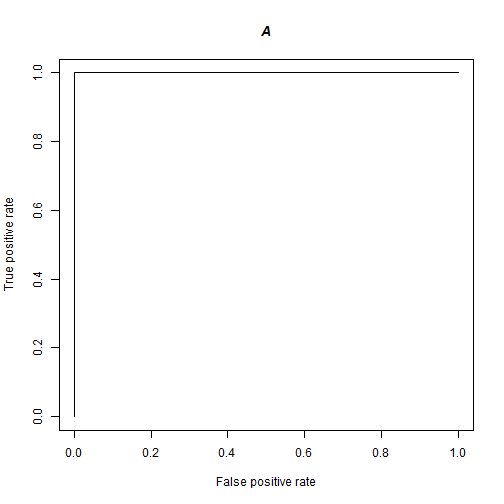

```r
raw_clean = raw[, c("roll_belt", "pitch_belt", "yaw_belt", "total_accel_belt", "gyros_belt_x", "gyros_belt_y", "gyros_belt_z", "accel_belt_x", "accel_belt_y", "accel_belt_z", "magnet_belt_x", "magnet_belt_y", "magnet_belt_z", "roll_arm", "pitch_arm", "yaw_arm", "total_accel_arm", "gyros_arm_x", "gyros_arm_y", "gyros_arm_z", "accel_arm_x", "accel_arm_y", "accel_arm_z", "magnet_arm_x", "magnet_arm_y", "magnet_arm_z", "roll_dumbbell", "pitch_dumbbell", "yaw_dumbbell", "total_accel_dumbbell", "gyros_dumbbell_x", "gyros_dumbbell_y", "gyros_dumbbell_z", "accel_dumbbell_x", "accel_dumbbell_y", "accel_dumbbell_z", "magnet_dumbbell_x", "magnet_dumbbell_y", "magnet_dumbbell_z", "roll_forearm", "pitch_forearm", "yaw_forearm", "total_accel_forearm", "gyros_forearm_x", "gyros_forearm_y", "gyros_forearm_z", "accel_forearm_x", "accel_forearm_y", "accel_forearm_z", "magnet_forearm_x", "magnet_forearm_y", "magnet_forearm_z", "classe")]; ## Only, store the columns of interest.
split = createDataPartition(y = raw_clean$classe, p = 0.70, list = FALSE);
split_training = raw_clean[split,];
split_testing = raw_clean[-split,];
train_model = train(classe ~ ., method = "rf", data = split_training, trControl = trainControl(method = "cv", number = 2, classProbs = TRUE));
predict_train_results = predict(train_model, split_testing, "prob");
roc_a = data.frame(predict_train_results$A, split_testing$classe == 'A');
colnames(roc_a) = c("predict", "label");
roc_b = data.frame(predict_train_results$B, split_testing$classe == 'B');
colnames(roc_b) = c("predict", "label");
roc_c = data.frame(predict_train_results$C, split_testing$classe == 'C');
colnames(roc_c) = c("predict", "label");
roc_d = data.frame(predict_train_results$D, split_testing$classe == 'D');
colnames(roc_d) = c("predict", "label");
roc_e = data.frame(predict_train_results$E, split_testing$classe == 'E');
colnames(roc_e) = c("predict", "label");
pred_a = prediction(roc_a$predict, roc_a$label);
perf_a = performance(pred_a, "tpr", "fpr");
pred_b = prediction(roc_b$predict, roc_b$label);
perf_b = performance(pred_b, "tpr", "fpr");
pred_c = prediction(roc_c$predict, roc_c$label);
perf_c = performance(pred_c, "tpr", "fpr");
pred_d = prediction(roc_d$predict, roc_d$label);
perf_d = performance(pred_d, "tpr", "fpr");
pred_e = prediction(roc_e$predict, roc_e$label);
perf_e = performance(pred_e, "tpr", "fpr");
plot(perf_a);
title(main = "A", font.main = 4);
```

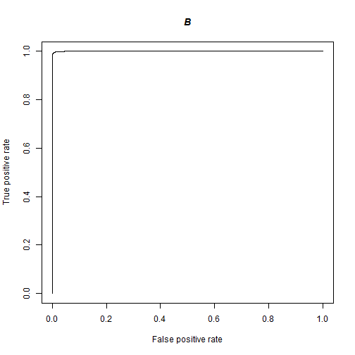

```r
plot(perf_b);
title(main = "B", font.main = 4);
```

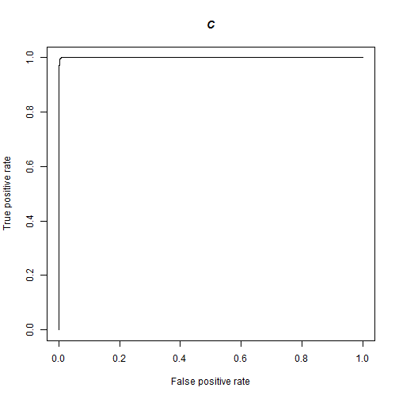

```r
plot(perf_c);
title(main = "C", font.main = 4);
```

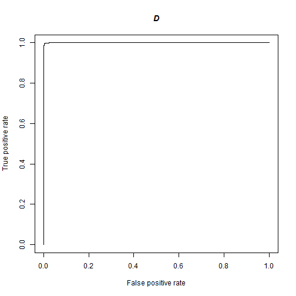

```r
plot(perf_d);
title(main = "D", font.main = 4);
```

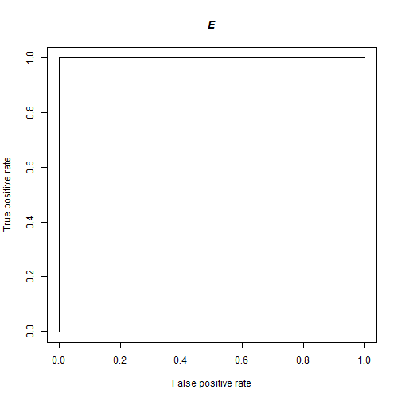

```r
plot(perf_e);
title(main = "E", font.main = 4);
```

## Conclusions

Though a range of experiments it was observed that only a K-fold of 2 was required.

The out-of-sample error is expected to be less than 1.0% on future unlabeled data.